# 부동산 데이터 분석

## 1. 개요

본 데이터는 국토교통부 실거래가 공개시스템의 2018.10.01 ~ 2019.09.30의 데이터 입니다.  
전반적인 데이터를 전처리, 및 시각화 해보았습니다.  
또한 Random Forest 모델을 적용해 지역별(구 기준), 건물의 층별 1평당 거래가격을 예측해보는 회귀모델을 생성 해보았습니다.  
부동산114라는 키워드로 포털사이트 뉴스정보를 크롤링하여 워드클라우드를 만들어 보았습니다.  
본 데이터의 참고사항은 다음과 같습니다.

- 본 서비스에서 제공하는 정보는 법적인 효력이 없으므로 참고용으로만 활용하시기 바랍니다.
- 신고정보가 실시간 변경, 해제되어 제공시점에 따라 공개건수 및 내용이 상이할 수 있는 점 참고하시기 바랍니다.
- 본 자료는 계약일 기준입니다. (※ 7월 계약, 8월 신고건 → 7월 거래건으로 제공)
- 통계자료 활용시에는 수치가 왜곡될 수 있으니 참고자료로만 활용하시기 바라며, 외부 공개시에는 반드시 신고일 기준으로 집계되는 공식통계를 이용하여 주시기 바랍니다.
- 주택매매 거래는 부동산 거래신고 등에 관한 법률 제3조에 따라 계약일로부터 60일 이내 신고토록 하고 있습니다.
- 국토교통부 실거래가 공개시스템의 궁금하신 점이나 문의사항은 콜센터 1588-0149로 연락 주시기 바랍니다.
- 검색조건 계약일자 : 20181001 ~ 20190930  
  실거래구분 : 아파트(매매)  
  주소구분 : 지번주소  
  시도 : 서울특별시  
  시군구 : 전체  
  읍면동 : 전체  
  면적 : 전체  
  금액선택 : 전체

## 2. 탐색적 자료 분석 (Exploratory Data Analysis)

회귀 모델을 만들기에 앞서 데이터 업로드 및 탐색적 자료 분석(EDA)를 해보았습니다. 컬럼의 종류, 컬럼의 자료형, 각 컬럼의 간단한 요약을 살펴보았습니다.  
탐색적 데이터 분석을 통해 어떠한 방향으로 데이터 분석을 해야할 지에 대해 생각해보았습니다.

- 어떤 동네의 집값이 가장 비쌀까, 그렇다면 비싼 이유는 무엇일까 ?
- 사람들이 가장 선호하는 층은 몇층일까 ?
- 대학생의 경우 개강시즌에 가장많이 원룸을 계약하는데 아파트는 어떨까 ?
- 최근 가장 거래가 활발한 곳은 어디일까, 활발한 이유는 무엇일까 ?

### 1) 필요한 패키지

```r
# 필요한패키지
library(dplyr) # data handling
library(ggplot2) # data visualization
library(stringr) # data handling
library(reshape2) # data handling
library(randomForest) # randomForest model
library(rvest) # web crawling
library(KoNLP) # elemental analysis
library(wordcloud) # wordcloud
library(RColorBrewer) # color
```

### 2) 데이터 업로드 및 데이터 파악

전반적인 데이터를 파악해보았을때 컬럼은 총 12개이며, 전용면적은 10.78m² ~ 317.36m², 건축년도는 1965 ~ 2019년, 층은 지하2 ~ 67층 까지로 나타났습니다.

```r
# 데이터 업로드
raw_property_df <- read.csv("property_181001_190930.csv", fileEncoding = "euc-kr")

# 데이터확인
head(raw_property_df)
```

```
##                     시군구  번지 본번 부번                   단지명
## 1 서울특별시 강남구 개포동 655-2  655    2   개포2차현대아파트(220)
## 2 서울특별시 강남구 개포동 658-1  658    1 개포6차우성아파트1동~8동
## 3 서울특별시 강남구 개포동 658-1  658    1 개포6차우성아파트1동~8동
## 4 서울특별시 강남구 개포동 658-1  658    1 개포6차우성아파트1동~8동
## 5 서울특별시 강남구 개포동 658-1  658    1 개포6차우성아파트1동~8동
## 6 서울특별시 강남구 개포동 658-1  658    1 개포6차우성아파트1동~8동
##   전용면적... 계약년월 계약일 거래금액.만원. 층 건축년도     도로명
## 1       77.75   201906     18        134,500  4     1988 언주로 103
## 2       67.28   201905      4        124,000  4     1987   언주로 3
## 3       79.97   201906     15        141,000  5     1987   언주로 3
## 4       79.97   201908     28        155,000  4     1987   언주로 3
## 5       79.97   201909      2        157,000  2     1987   언주로 3
## 6       79.97   201909     10        151,500  5     1987   언주로 3
```

```r
# 데이터 인덱스, 컬럼 파악
dim(raw_property_df)
```

```
## [1] 45994    12
```

```r
# 자료형 파악
str(raw_property_df)
```

```
## 'data.frame':    45994 obs. of  12 variables:
##  $ 시군구        : Factor w/ 316 levels "서울특별시 강남구 개포동",..: 1 1 1 1 1 1 1 1 1 1 ...
##  $ 번지          : Factor w/ 3908 levels "01월 01일","01월 03일",..: 2803 2814 2814 2814 2814 2814 2797 2797 2797 569 ...
##  $ 본번          : int  655 658 658 658 658 658 652 652 652 12 ...
##  $ 부번          : int  2 1 1 1 1 1 0 0 0 2 ...
##  $ 단지명        : Factor w/ 4658 levels "(1-102)","(1101-1)",..: 280 281 281 281 281 281 284 284 284 285 ...
##  $ 전용면적...   : num  77.8 67.3 80 80 80 ...
##  $ 계약년월      : int  201906 201905 201906 201908 201909 201909 201901 201906 201908 201906 ...
##  $ 계약일        : int  18 4 15 28 2 10 12 8 3 5 ...
##  $ 거래금액.만원.: Factor w/ 2437 levels "10,000","10,050",..: 322 232 387 475 484 456 743 484 602 827 ...
##  $ 층            : int  4 4 5 4 2 5 12 6 11 14 ...
##  $ 건축년도      : int  1988 1987 1987 1987 1987 1987 1984 1984 1984 2004 ...
##  $ 도로명        : Factor w/ 5559 levels " ","18","37",..: 3654 3663 3663 3663 3663 3663 262 262 262 269 ...
```

```r
# 데이터 요약
summary(raw_property_df)
```

```
##                       시군구           번지            본번
##  서울특별시 노원구 상계동: 1767   17     :  277   Min.   :   0.0
##  서울특별시 양천구 신정동:  979   22     :  211   1st Qu.: 170.0
##  서울특별시 노원구 중계동:  966   19     :  208   Median : 465.0
##  서울특별시 송파구 잠실동:  841   688    :  207   Mean   : 563.7
##  서울특별시 구로구 구로동:  824   13     :  202   3rd Qu.: 785.0
##  서울특별시 관악구 봉천동:  792   1013   :  191   Max.   :6040.0
##  (Other)                 :39825   (Other):44698
##       부번                 단지명       전용면적...        계약년월
##  Min.   :   0.000   현대      :  397   Min.   : 10.78   Min.   :201810
##  1st Qu.:   0.000   두산      :  352   1st Qu.: 59.61   1st Qu.:201903
##  Median :   0.000   한신      :  313   Median : 81.95   Median :201906
##  Mean   :   6.303   신동아    :  288   Mean   : 77.52   Mean   :201892
##  3rd Qu.:   1.000   삼성래미안:  278   3rd Qu.: 84.97   3rd Qu.:201907
##  Max.   :2837.000   파크리오  :  269   Max.   :317.36   Max.   :201909
##                     (Other)   :44097
##      계약일      거래금액.만원.        층            건축년도
##  Min.   : 1.00   60,000 :  707   Min.   :-2.000   Min.   :1965
##  1st Qu.: 8.00   90,000 :  456   1st Qu.: 4.000   1st Qu.:1993
##  Median :16.00   50,000 :  365   Median : 8.000   Median :2001
##  Mean   :16.12   40,000 :  357   Mean   : 9.283   Mean   :2000
##  3rd Qu.:24.00   70,000 :  338   3rd Qu.:13.000   3rd Qu.:2007
##  Max.   :31.00   80,000 :  338   Max.   :67.000   Max.   :2019
##                  (Other):43433
##              도로명
##  올림픽로 435   :  269
##  올림픽로 135   :  184
##  올림픽로 99    :  183
##  금하로 816     :  172
##  아리수로50길 50:  164
##  가재울미래로 2 :  160
##  (Other)        :44862
```

## 3. 데이터 처리 및 시각화

탐색적 데이터 분석 단계에서 확인 했을 때 데이터셋에서 모델을 만드는데 필요한 컬럼들을 생성 및 삭제를 진행했고, 어떠한 컬럼을 적용해야 하는지에 대해 시각화를 해보았습니다.

### 1) 데이터 처리

데이터의 처리에서는 시군구 컬럼의 분할, 번지,부번,도로명 등 다소 필요없는 컬럼들을 삭제, 자료형 변환을 통해 전반적인 data.frame을 수정해보았습니다.

```r
# 필요한 컬럼만 추출

raw_property_df <- cbind(raw_property_df$시군구,raw_property_df[,5:11])

# 시구동 분할

colname <- c("시", "구", "동")

mutate_df <- colsplit(raw_property_df[,1], " ", colname)

property_df <- cbind(mutate_df, raw_property_df[,2:8])

colnames(property_df) <- c("city", "gu", "dong", "apt_name", "use_area", "contract_ym", "contract_day", "transaction_cost", "floor", "architecture_year")

# ","제거 및 거래금액 컬럼을 숫자형으로 변환

property_df$transaction_cost <- property_df$transaction_cost %>%
  as.character() %>%
  str_replace_all(",", "") %>%
  as.numeric()

# 1평당 거래가격(cost_pyeong) 컬럼 생성

property_df <- mutate(property_df, cost_pyeong = property_df$transaction_cost / property_df$use_area *3.3)

# 거래량(count) 컬럼 생성

property_df <- mutate(property_df, count = 1)


# 자료형 factor로 변환

property_df$city <- property_df$city %>% as.factor()

property_df$gu <- property_df$gu %>% as.factor()

property_df$dong <- property_df$dong %>% as.factor()

property_df$contract_ym <- property_df$contract_ym %>% as.factor()

property_df$architecture_year <- property_df$architecture_year %>% as.factor()

# 자료형 확인
str(property_df)
```

```
## 'data.frame':    45994 obs. of  12 variables:
##  $ city             : Factor w/ 1 level "서울특별시": 1 1 1 1 1 1 1 1 1 1 ...
##  $ gu               : Factor w/ 25 levels "강남구","강동구",..: 1 1 1 1 1 1 1 1 1 1 ...
##  $ dong             : Factor w/ 314 levels "가락동","가리봉동",..: 9 9 9 9 9 9 9 9 9 9 ...
##  $ apt_name         : Factor w/ 4658 levels "(1-102)","(1101-1)",..: 280 281 281 281 281 281 284 284 284 285 ...
##  $ use_area         : num  77.8 67.3 80 80 80 ...
##  $ contract_ym      : Factor w/ 12 levels "201810","201811",..: 9 8 9 11 12 12 4 9 11 9 ...
##  $ contract_day     : int  18 4 15 28 2 10 12 8 3 5 ...
##  $ transaction_cost : num  134500 124000 141000 155000 157000 ...
##  $ floor            : int  4 4 5 4 2 5 12 6 11 14 ...
##  $ architecture_year: Factor w/ 54 levels "1965","1966",..: 23 22 22 22 22 22 19 19 19 39 ...
##  $ cost_pyeong      : num  5709 6082 5818 6396 6479 ...
##  $ count            : num  1 1 1 1 1 1 1 1 1 1 ...
```

### 2) 데이터 시각화

데이터 시각화에서는 다음과 같이 데이터를 시각화 해보았습니다.

- 구별 1평거래금액의 평균
- 층별 거래량
- 건축년도별 평당가격평균
- 거래량(월별, 구별)
- 전용면적별 거래량(어떤 면적의 거래량이 많은지)

#### 2-1 구별 거래금액의 평균

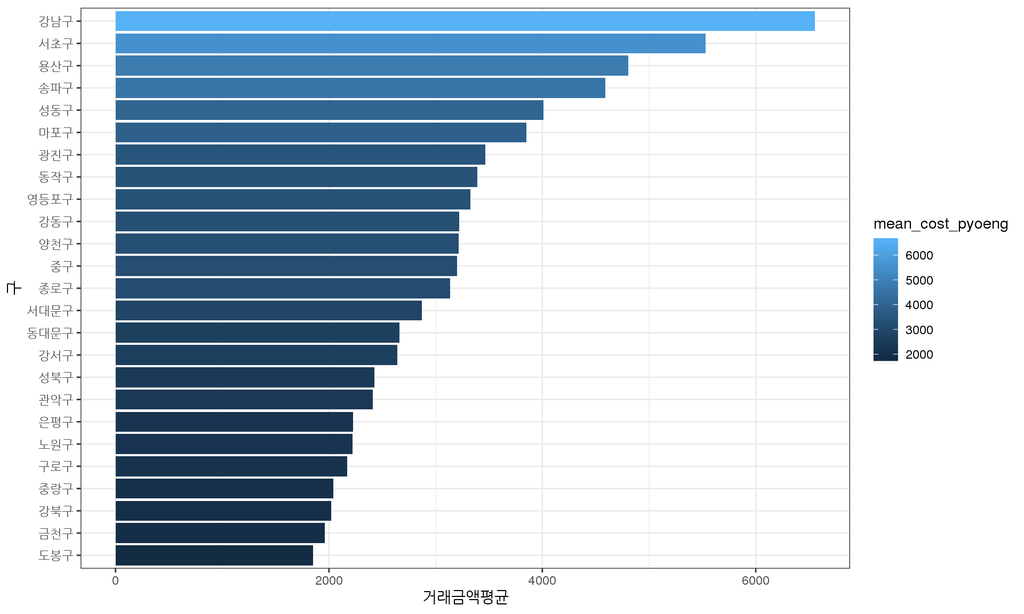

```r
# 구별 거래금액의 평균
gu_cost_data <- property_df %>%
  group_by(gu) %>%
  summarise(mean_cost_pyoeng = mean(cost_pyeong)) %>%
  arrange(desc(mean_cost_pyoeng)) %>%
  as.data.frame()

ggplot(data = gu_cost_data, aes(x = reorder(gu,mean_cost_pyoeng), y = mean_cost_pyoeng,
                                fill = mean_cost_pyoeng)) +
  xlab("구") +
  ylab("거래금액평균") +
  geom_bar(stat = "identity") +
  coord_flip() +
  theme_bw()
```

#### 2-2 층별 거래량

거래량을 층별로 구분지어 보았을때 1~5층이 가장 많은 거래량이 발생한 것으로 나타났습니다.  
또한 고층으로 갈수록 거래량이 감소하는 형태를 보이고 있는데 이는 사람들이 고층보다 저층을 선호한다는 것으로는 보기 어렵습니다. 그 이유는 기존의 아파트는 보통 약 15층 정도로 많이 건설되었고, 최근에 고층아파트들이 늘어나는 추세이기 때문에 이 부분은 최근 1년 데이터만으로는 판단하기 어렵고 수년, 수십년전부터 데이터를 종합하여 고층건물의 비율 과 그 거래량의 증가, 감소를 살펴보아야 판단가능한 부분이라고 생각합니다.

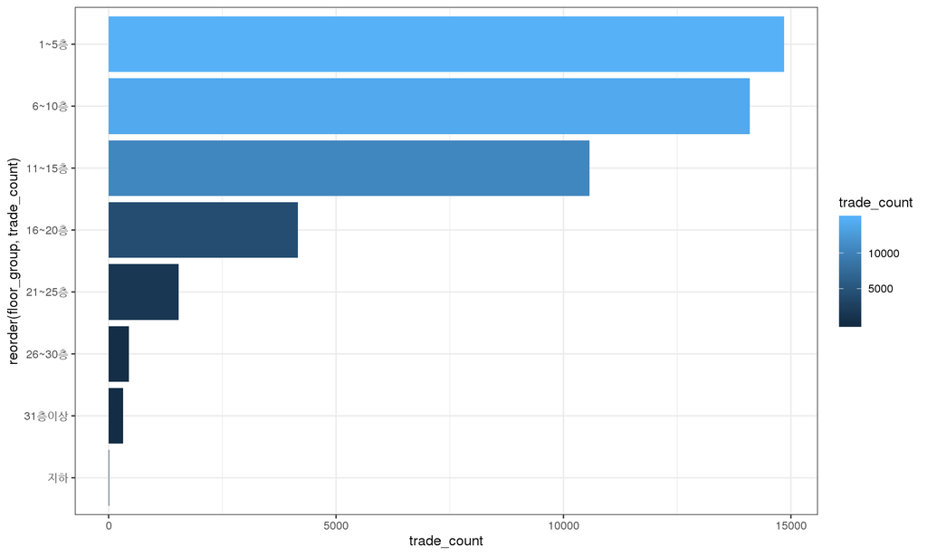

```r
# 층 그룹화
property_df$floor_group <- ifelse(property_df$floor <= 0, "지하",
                   ifelse(property_df$floor <= 5,"1~5층",
                    ifelse(property_df$floor <= 10,"6~10층",
                    ifelse(property_df$floor <= 15,"11~15층",
                    ifelse(property_df$floor <= 20,"16~20층",
                    ifelse(property_df$floor <= 25,"21~25층",
                    ifelse(property_df$floor <= 30,"26~30층","31층이상")))))))
# 층별 거래량
floor_group_ggplot <- property_df %>%
  group_by(floor_group) %>%
  summarise(trade_count = sum(count)) %>%
  arrange(desc(trade_count)) %>%
            as.data.frame()

ggplot(data = floor_group_ggplot, aes(x = reorder(floor_group,trade_count), y = trade_count ,
                                      fill = trade_count )) +
  geom_bar(stat = "identity") +
  coord_flip() +
  theme_bw()
```

#### 2-3 건축년도별 거래량, 거래금액평균

건축년도별 거래량, 거래금액평균을 살펴보았을때 건축년도가 거래금액의 책정에 영향을 미치긴 어렵다는 판단입니다. 그래프를 살펴보았을때 거래량은 2004년건축, 거래금액평균은 1982년건축이 가장 높은것으로 나왔습니다. 이는 건축년도가 가격에 많은 영향을 미치기 보다는 다른 변수가 가격결정의 요인이 되는 것으로 보여집니다.

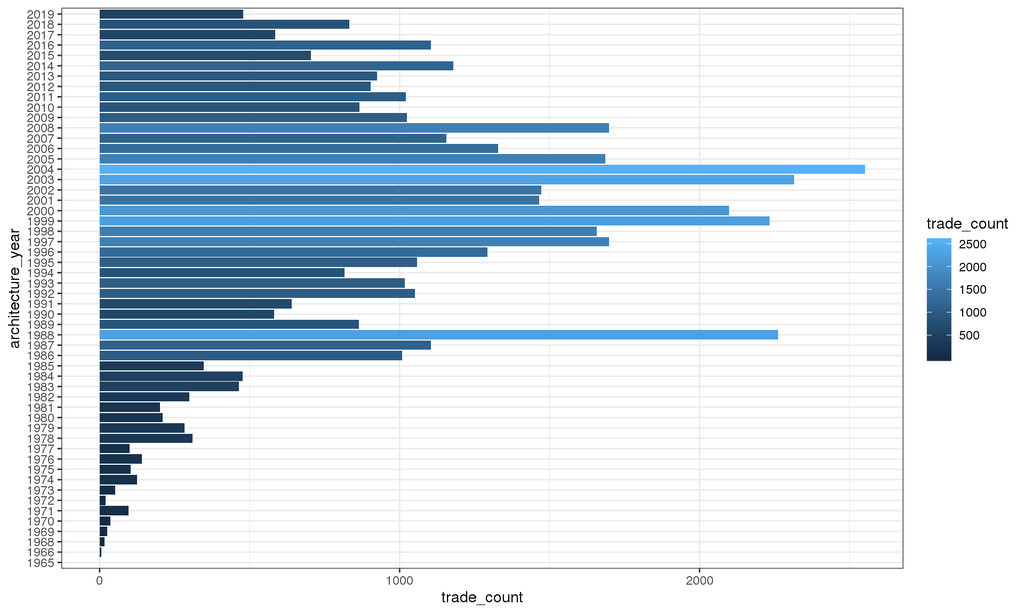

```r
# 건축년도별 거래량
architecture_year_count_ggplot <- property_df %>%
  group_by(architecture_year) %>%
  summarise(trade_count = sum(count)) %>%
  arrange(desc(trade_count)) %>%
            as.data.frame()

# 건축년도별 거래금액평균
architecture_year_cost_ggplot <- property_df %>%
  group_by(architecture_year) %>%
  summarise(mean_cost_pyeong = mean(cost_pyeong)) %>%
  arrange(desc(mean_cost_pyeong)) %>%
            as.data.frame()

ggplot(data = architecture_year_count_ggplot, aes(x = architecture_year,
                                                  y = trade_count ,
                                                  fill = trade_count )) +
  geom_bar(stat = "identity") +
  coord_flip() +
  theme_bw()
```

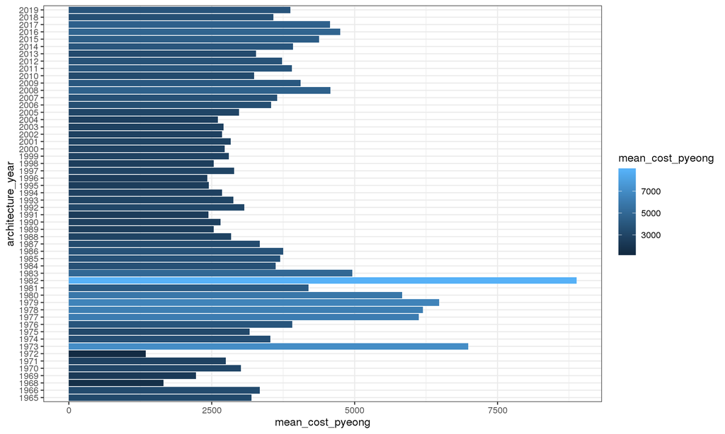

```r
ggplot(data = architecture_year_cost_ggplot, aes(x = architecture_year,
                                                 y = mean_cost_pyeong ,
                                                 fill = mean_cost_pyeong )) +
  geom_bar(stat = "identity") +
  coord_flip() +
  theme_bw()
```

#### 2-4 구별, 월별 거래량

구별 거래량을 살펴보았을 때 노원구 1위, 송파구 2위, 강남구 3위로 나타났습니다.  
월별 거래량을 살펴보았을 때 6~8월 여름시즌에 거래량이 높고 11~1월 겨울시즌에 거래량이 낮은 형태를 볼 수 있습니다. 이러한 데이터를 기반으로 계절에 따라 마케팅 수단을 달리 취하여 부동산시장을 활발하게 할 수 있을 것입니다.

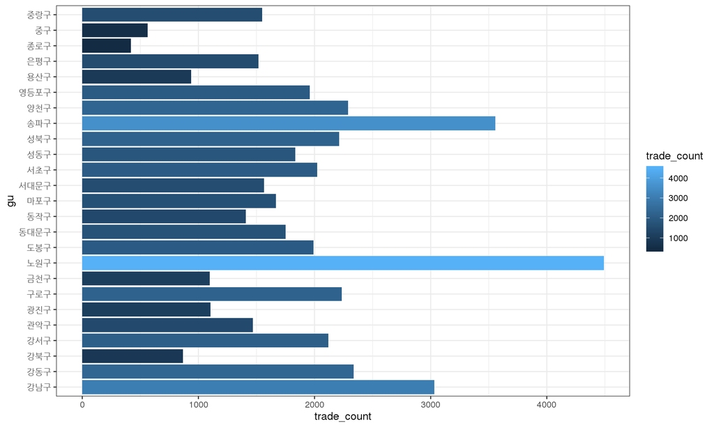

```r
# 구별 거래량
gu_trade_count <- property_df %>%
  group_by(gu) %>%
  summarise(trade_count = sum(count)) %>%
  as.data.frame()

ggplot(data = gu_trade_count, aes(x = gu, y = trade_count, fill = trade_count)) +
  geom_bar(stat = "identity") +
  coord_flip() +
  theme_bw()
```

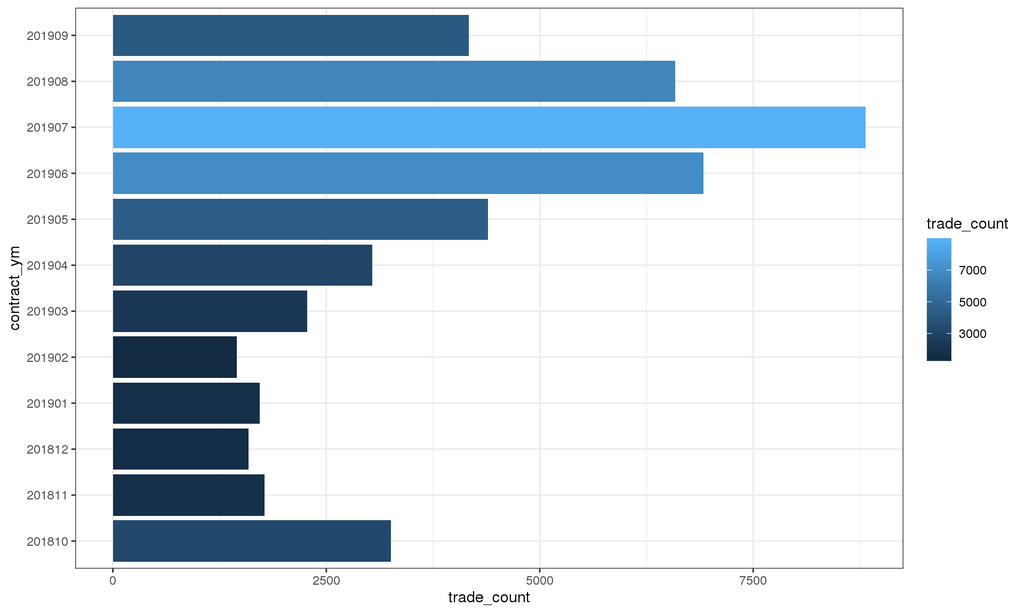

```r
# 월별 거래량

month_trade_count <- property_df %>%
  group_by(contract_ym) %>%
  summarise(trade_count = sum(count)) %>%
  as.data.frame()

 ggplot(data = month_trade_count, aes(x = contract_ym , y = trade_count, fill = trade_count)) +
  geom_bar(stat = "identity") +
  coord_flip() +
  theme_bw()
```

#### 2-5 전용면적별 거래량

전용면적별 거래량을 보았을때 21 ~ 30평이 18720개로 1위, 11 ~ 20평이 17351로 2위를 기록했습니다. 10평 미만평수를 제외한 비교적 작은 평수에서 잦은 상당히 많은 거래량이 발생하게 되는데, 이는 가족의 형태와 관련이 있다고 생각합니다. 집을 구할때 신혼부부나 어린 아이가 있는 가족이 비교적 작은 집에 계약을 하게 되는데 아이를 출산하여 가족구성원이 늘어나거나 아이가 자라 더 큰집이 필요로 하기에 집을 매매하는 경향이 있다고 예상해 볼 수 있습니다. 또한 이들이 젊은 부부라고 가정했을때 이들의 이직이나 보유자산 등 정리되지 않은 불완전한 상황을 고려하여 잦은 이사를 할 수 있다고 예상해 볼 수 있습니다. 그에 반해 평수가 높아질 수록 거래량이 급격하게 줄어들게 되는데 높은 평수의 아파트 증가율 과 그 거래량의 상관관계를 고려해보야 할 문제이지만, 어느정도 생활의 안정화가 되어 잦은 이사를 하지 않는 것으라고 생각해 볼 수 있을 것 같습니다.

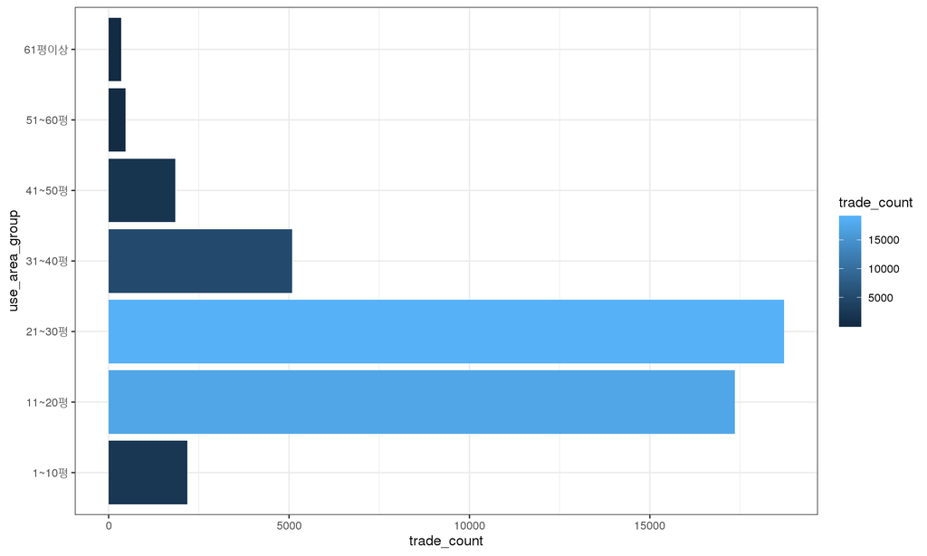

```r
# 전용면적별 그룹화
property_df$use_area_group <- ifelse(property_df$use_area <= 33, "1~10평",
                   ifelse(property_df$use_area <= 66,"11~20평",
                    ifelse(property_df$use_area <= 99,"21~30평",
                    ifelse(property_df$use_area <= 132,"31~40평",
                    ifelse(property_df$use_area <= 165,"41~50평",
                    ifelse(property_df$use_area <= 198,"51~60평","61평이상"))))))

# 전용면적별 거래량
use_area_trade_count <- property_df %>%
  group_by(use_area_group) %>%
  summarise(trade_count = sum(count)) %>%
  arrange(desc(trade_count)) %>%
            as.data.frame()

ggplot(data = use_area_trade_count, aes(x = use_area_group, y = trade_count ,
                                      fill = trade_count )) +
  geom_bar(stat = "identity") +
  coord_flip() +
  theme_bw()
```

## 4. RandomForest 모델

모델은 독립변수인 구, 층 으로 종속변수인 평당거래금액을 회귀하는 randomForest 모델을 사용했습니다. importance와 varImpPlot을 살펴보았을때 아파트가 어디구에 위치해있는가가 가격을 결정하는대에 가장큰 영향을 주었고, 층이라는 변수는 구에 비해 매우 낮은 영향력을 보였습니다.

```r
# data 생성
df <- property_df

# train/test sampling
training_sampling <- sort(sample(1:nrow(df), nrow(df) * 0.7 ))
test_sampling <- setdiff(1:nrow(df),training_sampling)

# traning_set, test_set
training_set <- df[training_sampling,]
test_set <- df[test_sampling,]

# randomForest model
rf_m <- randomForest(cost_pyeong ~ gu + floor , data = training_set)

# importance
rf_importance <- randomForest(cost_pyeong ~ gu + floor , data = training_set, importance = TRUE)

importance(rf_m)
```

```
##       IncNodePurity
## gu      52152744984
## floor    2531446154
```

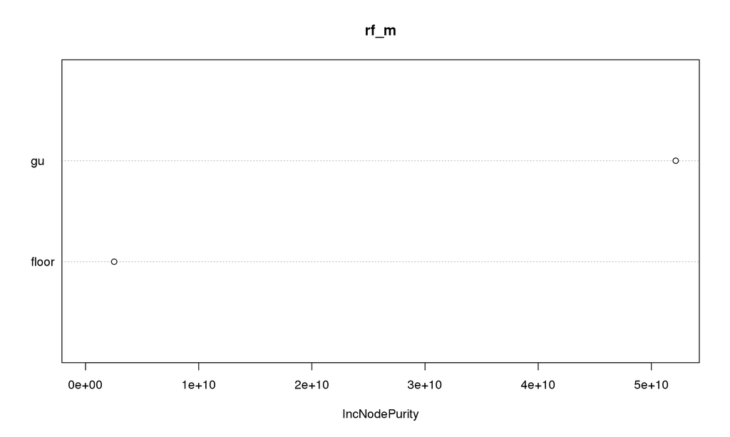

```r
varImpPlot(rf_m)
```

```r
# predict cost
rf_p <- predict(rf_m, newdata = test_set, type = "class")

# predict dataframe 생성
predict_df <- cbind(cost_pyeong = test_set$cost_pyeong, p_cost_pyeong = rf_p) %>%
  as.data.frame()

# 오차 컬럼 생성
predict_df <- mutate(predict_df, error = abs(cost_pyeong - p_cost_pyeong))
mean(predict_df$error)
```

```
## [1] 812.6121
```

```r
# 요약
summary(predict_df$error)
```

```
##      Min.   1st Qu.    Median      Mean   3rd Qu.      Max.
##     0.041   265.672   569.856   812.612  1062.093 11135.577
```

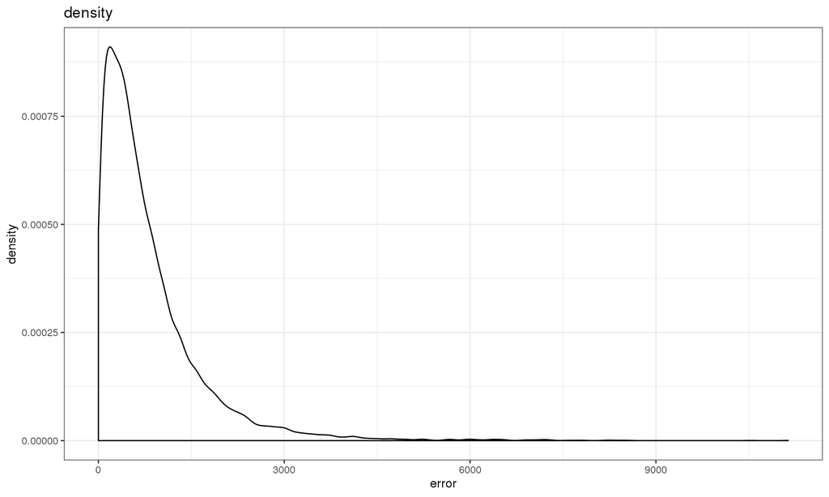

```r
# error density ggplot
predict_df$error <- predict_df$error %>% as.numeric()

ggplot (data=predict_df, aes (x= error)) +
  geom_density() +
  ggtitle("density") +
  theme_bw()
```

```r
# Root Mean Squared Error
RMSE <- function(error) { sqrt(mean(error^2)) }
RMSE(predict_df$error)
```

```
## [1] 1181.257
```

```r
# Mean Absolute Error
mae <- function(error) { mean(abs(error)) }
mae(predict_df$error)
```

```
## [1] 812.6121
```

## 6. 부동산 뉴스 wordcloud

웹 크롤링을 사용하여 부동산114라는 키워드의 뉴스들의 형태소를 분석하여 자주나오는 단어들로 wordcloud를 만들어 보았습니다.

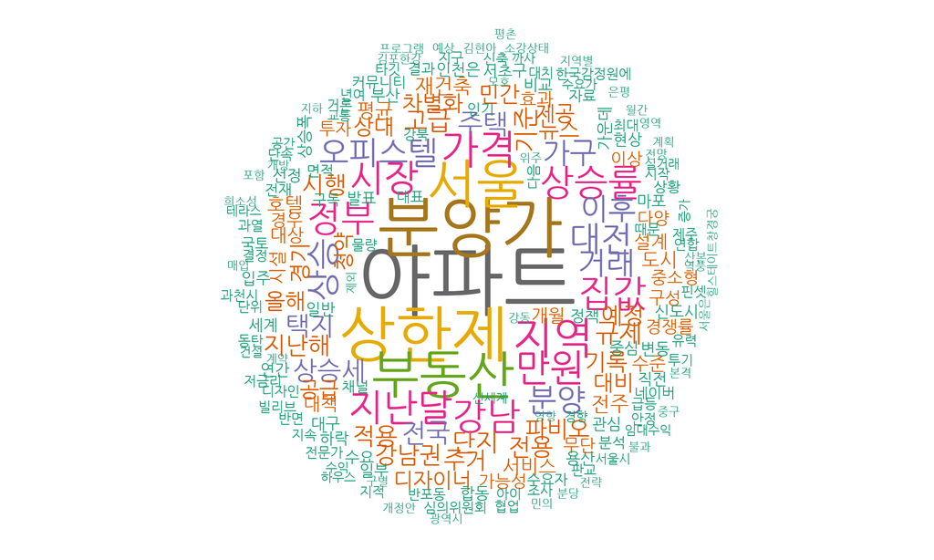

```r
page_list <- c(1:3)

news_text_list <- c()

for (page in page_list) {
estate_url <- paste0("https://search.naver.com/search.naver?&where=news&query=%EB%B6%80%EB%8F%99%EC%82%B0%20114&sm=tab_pge&sort=0&photo=0&field=0&reporter_article=&pd=0&ds=&de=&docid=&nso=so:r,p:all,a:all&mynews=0&cluster_rank=17&start=",page,"&refresh_start=0")


estate_html <- read_html(estate_url)

estate_urls <- estate_html %>%
  html_nodes(".type01") %>%
  html_nodes("a") %>%
  html_attr("href") %>%
  unique()


estate_urls <- estate_urls[grep("naver.com",estate_urls)]


news_text <- lapply(estate_urls, function(news_page){
  news_page %>%
    read_html() %>%
    html_nodes("#articleBodyContents._article_body_contents") %>%
    html_text()
})



news_text <- news_text %>%
  unlist() %>%
  str_replace_all("flash 오류를 우회하기 위한 함수 추가","") %>%
  str_replace_all("function _flash_removeCallback","") %>%
  str_replace_all("동영상 뉴스","") %>%
  str_replace_all("\\W"," ") %>%
  str_replace_all("[[A-Za-z]]"," ") %>%
  str_replace_all("\\d"," ") %>%
  str_replace_all("  "," ")  %>%
  unique()

news_text_list <- append(news_text_list,news_text)

Sys.sleep(20)
}

word.freq <- paste0(news_text_list[1:12],collapse = " ")


nouns <- KoNLP::extractNoun(word.freq)


nouns <- nouns[nchar(nouns) >= 2]

wordcount <- table(unlist(nouns))

df.word  <- as.data.frame(wordcount, stringsAsFactors = FALSE)
df.word <- rename(df.word, word = Var1, freq = Freq)

word.freq  <- df.word %>%
  filter(freq >= 2) %>%
  arrange(desc(freq))


wordcloud::wordcloud(words = word.freq$word, freq = word.freq$freq,
                     min.freq = 2, max.words = 200,
                     random.order = FALSE, rot.per = 0.1,
                     scale= c(5,0.5),
                     colors = brewer.pal(8, "Dark2"))
```